```r
# Set up the default parameters
# 1. The code block will be shown in the document
# 2. set up figure display size
# 3. turn off all the warnings and messages

knitr::opts_chunk$set(echo = TRUE)
knitr::opts_chunk$set(fig.width = 8, fig.height = 4)
knitr::opts_chunk$set(warning = FALSE, message = FALSE)
```

# Background

```r
library(zoo)
library(lubridate)
library(mgcv)
library(ggplot2)
library(forecast)
```

# Instructions on reading the data

To read the data in `R`, save the file in your working directory (make sure you have changed the directory if different from the R working directory) and read the data using the `R` function `read.csv()`

```r
daily <- read.csv("DailyCurrencyData.csv", head = TRUE)
monthly <- read.csv("MonthlyCurrencyData.csv", head = TRUE)

daily$Date <- as.Date(daily$Date, "%Y-%m-%d")
monthly$Date <- as.Date(paste0(monthly$Date, "-01"), "%Y-%m-%d")
colnames(monthly) <- colnames(daily)
```

# Question 1. Weekly vs Monthly Exploratory Data Analysis (20 points)

**1a.** Based on your intuition, when would you use weekly instead of monthly time series data?

*Response*

Weekly data could be used if there is expected seasonality or trend on a weekly basis. By aggregating to monthly you could be reducing insights that might be available in the weekly data.

**1b.** Plot the time series plots for both currency exchange rates comparing weekly vs monthly data. How do the weekly and monthly time series data compare? How do the time series for the two currencies compare?

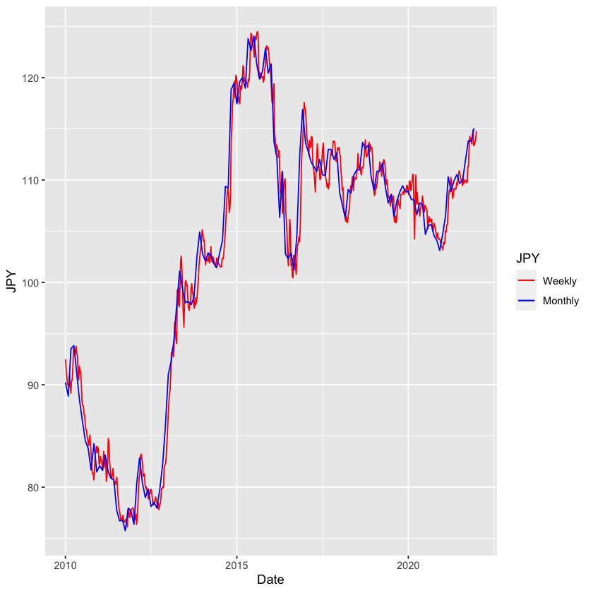

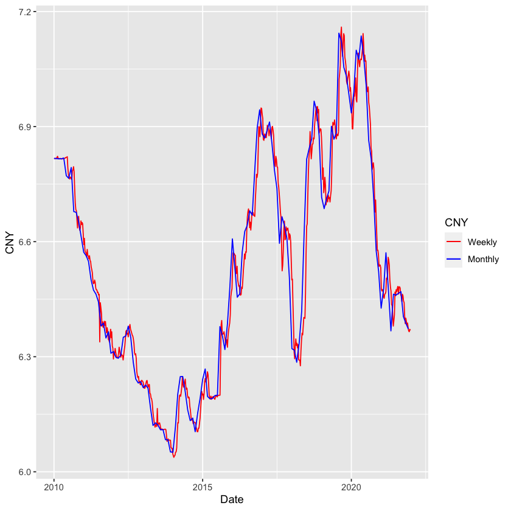

```r
daily <- na.locf(daily)

weekly <- daily
weekly$Date <- floor_date(weekly$Date, "week")
weekly <- aggregate(weekly[, 2:3], by = list(weekly$Date), FUN = mean)
colnames(weekly)[1] <- "Date"

ggplot() +
  geom_line(data = weekly, aes(x = Date, y = JPY, color="Weekly")) +
  geom_line(data = monthly, aes(x = Date, y = JPY, color = "Monthly")) +
  xlab('Date') +
  ylab('JPY') + scale_color_manual(name='JPY',
                     breaks=c('Weekly', 'Monthly'),
                     values=c('Weekly'='red', 'Monthly'='blue'))

ggplot() +
  geom_line(data = weekly, aes(x = Date, y = CNY, color="Weekly")) +
  geom_line(data = monthly, aes(x = Date, y = CNY, color = "Monthly")) +
  xlab('Date') +
  ylab('CNY') + scale_color_manual(name='CNY',
                     breaks=c('Weekly', 'Monthly'),
                     values=c('Weekly'='red', 'Monthly'='blue'))
```

*Response: Weekly vs Montly Time Series data comparison*

In both CNY and JPY datasets the weekly data shows large variation whereas the monthly data is much smoother. This is expected by because the monthly data takes is a more agglomerated view of the weekly data which smoooths the data. We could see even more smoothing by agglomerating the monthly data to yearly.

**1c.** Fit a non-parametric trend using splines regression to both the weekly and monthly time series data for both currencies. Overlay the fitted trends for each of the currency separately. How do the trends compare when comparing those fitted using the weekly and monthly data? How do the trends for the two currencies compare?

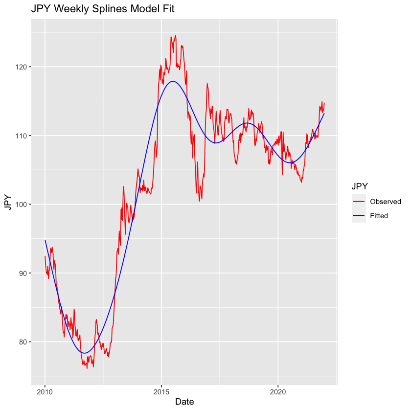

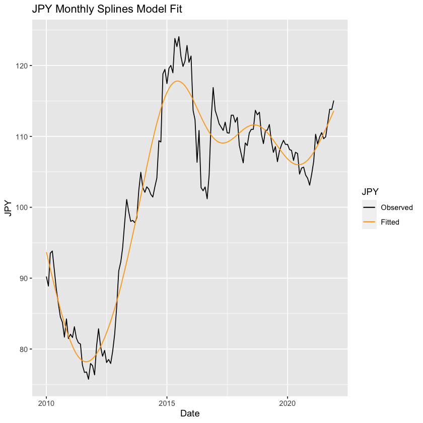

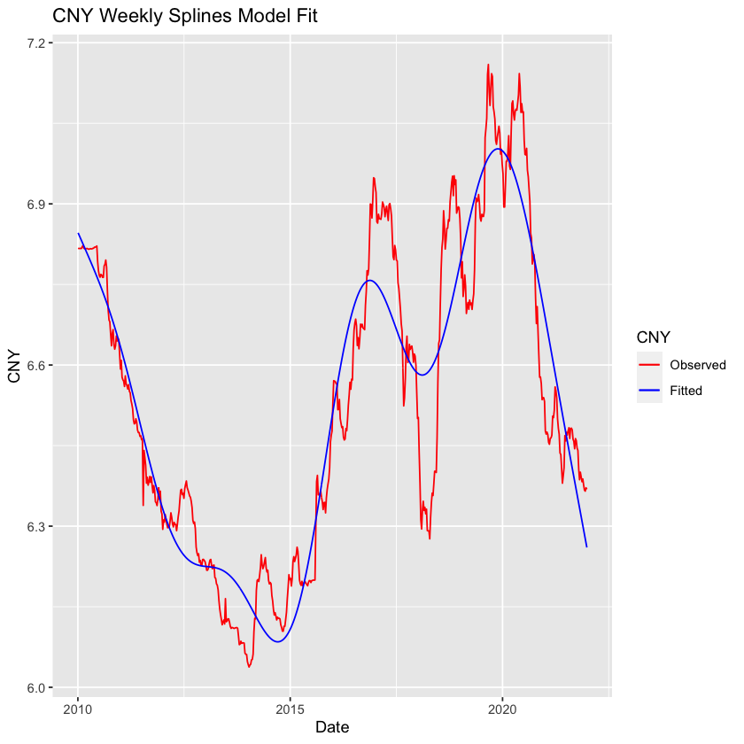

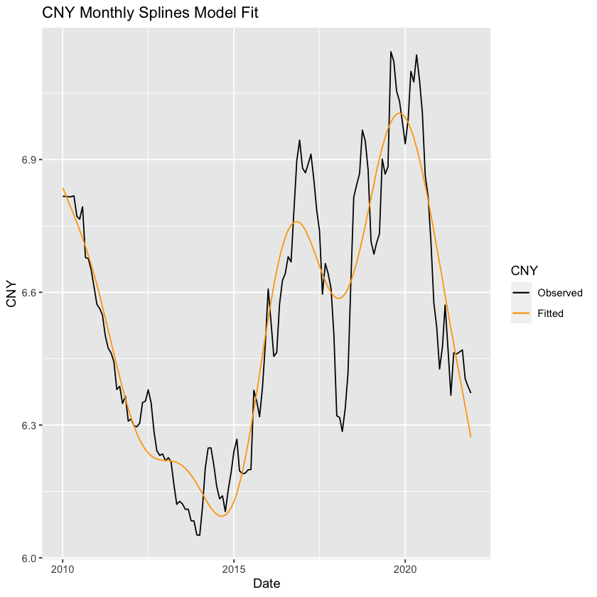

```r
## JPY Weekly Data

# Vector of 1 to the length of weekly JPY data
points <- 1:length(weekly$JPY)

# Create splines model on weekly JPY data
gam.jpy.weekly <- gam(weekly$JPY ~ s(points))

# Fit data to splines model
gam.fit.jpy.weekly <- ts(fitted(gam.jpy.weekly), start = 2010, frequency = 52)

#Plot Weekly
ggplot() +
  geom_line(data = weekly, aes(x = Date, y = JPY, color="Observed")) +
  geom_line(aes(x = weekly$Date, y = gam.fit.jpy.weekly, color = "Fitted")) +
  xlab('Date') +
  ylab('JPY') + labs(title = 'JPY Weekly Splines Model Fit') + scale_color_manual(name='JPY',
                     breaks=c('Observed', 'Fitted'),
                     values=c('Observed'='red', 'Fitted'='blue'))

## JPY Monthly Data

# Vector of 1 to the length of weekly JPY data
points <- 1:length(monthly$JPY)

# Create splines model on weekly JPY data
gam.jpy.monthly <- gam(monthly$JPY ~ s(points))

# Fit data to splines model
gam.fit.jpy.monthly <- ts(fitted(gam.jpy.monthly), start = 2010, frequency = 12)

#Plot Monthly
ggplot() +
  geom_line(data = monthly, aes(x = Date, y = JPY, color="Observed")) +
  geom_line(aes(x = monthly$Date, y = gam.fit.jpy.monthly, color = "Fitted")) +
  xlab('Date') +
  ylab('JPY') + labs(title = 'JPY Monthly Splines Model Fit') + scale_color_manual(name='JPY',
                     breaks=c('Observed', 'Fitted'),
                     values=c('Observed'='black', 'Fitted'='orange'))

## CNY Weekly Data

# Vector of 1 to the length of weekly CNY data
points <- 1:length(weekly$CNY)

# Create splines model on weekly CNY data
gam.cny.weekly <- gam(weekly$CNY ~ s(points))

# Fit data to splines model
gam.fit.cny.weekly <- ts(fitted(gam.cny.weekly), start = 2010, frequency = 52)

#Plot Weekly
ggplot() +
  geom_line(data = weekly, aes(x = Date, y = CNY, color="Observed")) +
  geom_line(aes(x = weekly$Date, y = gam.fit.cny.weekly, color = "Fitted")) +
  xlab('Date') +
  ylab('CNY') + labs(title = 'CNY Weekly Splines Model Fit') + scale_color_manual(name='CNY',
                     breaks=c('Observed', 'Fitted'),
                     values=c('Observed'='red', 'Fitted'='blue'))

## CNY Monthly Data

# Vector of 1 to the length of weekly CNY data
points <- 1:length(monthly$CNY)

# Create splines model on weekly CNY data
gam.cny.monthly <- gam(monthly$CNY ~ s(points))

# Fit data to splines model
gam.fit.cny.monthly <- ts(fitted(gam.cny.monthly), start = 2010, frequency = 12)

#Plot Monthly
ggplot() +
  geom_line(data = monthly, aes(x = Date, y = CNY, color="Observed")) +
  geom_line(aes(x = monthly$Date, y = gam.fit.cny.monthly, color = "Fitted")) +
  xlab('Date') +
  ylab('CNY') + labs(title = 'CNY Monthly Splines Model Fit') + scale_color_manual(name='CNY',
                     breaks=c('Observed', 'Fitted'),
                     values=c('Observed'='black', 'Fitted'='orange'))
```

*Response: Comparing Trend Estimation using weekly vs Monthly Data*

The trend estimation between the weekly and monthly data is very similar for both currencies. The splines fit does not show significant change whether the weekly or monthly data is being used.

**1d.** Take the 1st order difference of the time series weekly vs monthly data. Plot the ACF plots and compare. How do the difference time series for weekly and monthly data compare in terms of stationarity? How do the difference time series for the two currencies compare in terms of serial dependence and stationarity?

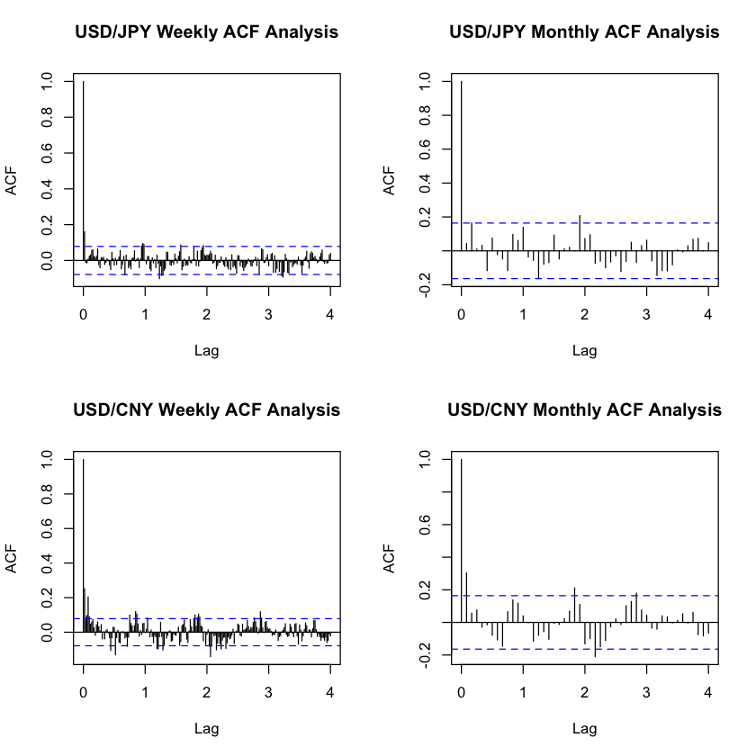

```r
weekly.ts.jpy = ts(weekly$JPY, start=2010, frequency=52)
weekly.ts.cny = ts(weekly$CNY, start=2010, frequency=52)
monthly.ts.jpy = ts(monthly$JPY, start=2010, frequency=12)
monthly.ts.cny = ts(monthly$CNY, start=2010, frequency=12)

par(mfrow = c(2, 2))

acf(diff(weekly.ts.jpy), lag.max = 52 * 4, xlab = "Lag", ylab = "ACF", main = "USD/JPY Weekly ACF Analysis")
acf(diff(monthly.ts.jpy), lag.max = 12 * 4, xlab = "Lag", ylab = "ACF", main = "USD/JPY Monthly ACF Analysis")

acf(diff(weekly.ts.cny), lag.max = 52 * 4, xlab = "Lag", ylab = "ACF", main = "USD/CNY Weekly ACF Analysis")
acf(diff(monthly.ts.cny), lag.max = 12 * 4, xlab = "Lag", ylab = "ACF", main = "USD/CNY Monthly ACF Analysis")
```

*Response: Exploratory Analysis of 1st Order Difference Data*

The ACF plot of all first order differences show a weekly stationarity process. The ACF function rarely shows any large negative or positive peaks although there does seem to be some serial dependence in the CNY plots. As expected, the trend is reduced through differencing

In the weekly data, inflection points can be seen at the following lags (0.25, 0.75, 1, 1.5, 2, 2.5, 3). There does seem to be some cyclical pattern to the ACF plot.

In the monthly data inflection points can be seen at roughtly the same lags indicating that aggregating the data did not eliminate the potentail seasonality in the data.

# Question 2. ARIMA Fitting and Forecasting: Weekly Data Analysis (23 points)

**2a.** Divide the data into training and testing data set, where the training data exclude the last eight weeks of data (November and December 2021) with the testing data including the last eight weeks of data. For both currency exchange rates and using the training datasets, use the iterative model to fit an ARIMA(p,d,q) model with max AR and MA orders of 8, and a differencing order of 1 or 2. Display the summary of the final model fit. Compare statistical significance of the coefficients. Would a lower order model be suggested based on the statistical significance of the coefficients?

*Analyzing weekly data with ARIMA model fitting*

```r
options(warn = -1)
weekly.train = head(weekly, n=length(weekly$Date)-8)
weekly.test = tail(weekly, n=8)

norderpq = 8
norderd = 2


p = c(1:norderpq)-1; q = c(1:norderpq)-1; d = c(1:norderd)

aic1 = matrix(0, norderpq, norderpq)
aic2 = matrix(0, norderpq, norderpq)

for (i in 1:norderpq){
    for (j in 1:norderpq){
        for (k in 1:norderd){
            modijk = arima(weekly.test$JPY, order = c(p[i], d[k], q[j]), method = 'ML')
            if (k == 1){
                aic1[i,j] = modijk$aic-2*(p[i]+q[j]+1)+2*(p[i]+q[j]+1)*length(weekly.train)/(length(weekly.train)-p[i]-q[j]-2)
            } else {
                aic2[i,j] = modijk$aic-2*(p[i]+q[j]+1)+2*(p[i]+q[j]+1)*length(weekly.train)/(length(weekly.train)-p[i]-q[j]-2)
            }
        }
    }
}

aicv1 = as.vector(aic1)
indexp1 = rep(c(1:norderpq),norderpq)
indexq1 = rep(c(1:norderpq),each=norderpq)
indexaic1 = which(aicv1 == min(aicv1))
porder1 = indexp1[indexaic1]-1
qorder1 = indexq1[indexaic1]-1

minaic1 = aic1[porder1+1,qorder1+1]

aicv2 = as.vector(aic2)
indexp2 = rep(c(1:norderpq),norderpq)
indexq2 = rep(c(1:norderpq),each=norderpq)
indexaic2 = which(aicv2 == min(aicv2))
porder2 = indexp2[indexaic2]-1
qorder2 = indexq2[indexaic2]-1

minaic2 = aic1[porder2+1,qorder2+1]

if (minaic1 < minaic2){
    final_model_jp = arima(weekly.train$JPY, order = c(porder1, 1, qorder1), method = 'ML')
    porderjp = porder1
    qorderjp = qorder1
} else {
    final_model_jp = arima(weekly.train$JPY, order = c(porder2, 2, qorder2), method = 'ML')
    porderjp = porder2
    qorderjp = qorder2
}
```

```r
options(warn = -1)
weekly.train = head(weekly, n=length(weekly$Date)-8)
weekly.test = tail(weekly, n=8)

norderpq = 8
norderd = 2


p = c(1:norderpq)-1; q = c(1:norderpq)-1; d = c(1:norderd)

aic1 = matrix(0, norderpq, norderpq)
aic2 = matrix(0, norderpq, norderpq)

for (i in 1:norderpq){
    for (j in 1:norderpq){
        for (k in 1:norderd){
            modijk = arima(weekly.test$CNY, order = c(p[i], d[k], q[j]), method = 'ML')
            if (k == 1){
                aic1[i,j] = modijk$aic-2*(p[i]+q[j]+1)+2*(p[i]+q[j]+1)*length(weekly.train)/(length(weekly.train)-p[i]-q[j]-2)
            } else {
                aic2[i,j] = modijk$aic-2*(p[i]+q[j]+1)+2*(p[i]+q[j]+1)*length(weekly.train)/(length(weekly.train)-p[i]-q[j]-2)
            }
        }
    }
}

aicv1 = as.vector(aic1)
indexp1 = rep(c(1:norderpq),norderpq)
indexq1 = rep(c(1:norderpq),each=norderpq)
indexaic1 = which(aicv1 == min(aicv1))
porder1 = indexp1[indexaic1]-1
qorder1 = indexq1[indexaic1]-1

minaic1 = aic1[porder1+1,qorder1+1]

aicv2 = as.vector(aic2)
indexp2 = rep(c(1:norderpq),norderpq)
indexq2 = rep(c(1:norderpq),each=norderpq)
indexaic2 = which(aicv2 == min(aicv2))
porder2 = indexp2[indexaic2]-1
qorder2 = indexq2[indexaic2]-1

minaic2 = aic1[porder2+1,qorder2+1]

if (minaic1 < minaic2){
    final_model_cn = arima(weekly.train$CNY, order = c(porder1, 1, qorder1), method = 'ML')
    pordercn = porder1
    qordercn = qorder1
} else {
    final_model_cn = arima(weekly.train$CNY, order = c(porder2, 2, qorder2), method = 'ML')
    pordercn = porder2
    qordercn = qorder2
}
```

```r
summary(final_model_jp)

summary(final_model_cn)
```

```
Call:
arima(x = weekly.train$JPY, order = c(porder1, 1, qorder1), method = "ML")

Coefficients:
         ar1     ar2      ar3     ar4      ar5      ma1      ma2     ma3
      1.0040  0.7373  -1.0295  0.1901  -0.0294  -0.8572  -0.9122  0.9369
s.e.  0.0734  0.0509   0.0748  0.0579   0.0436   0.0655      NaN  0.0676

sigma^2 estimated as 1.039:  log likelihood = -887.35,  aic = 1792.7

Training set error measures:
                     ME     RMSE       MAE        MPE      MAPE      MASE
Training set 0.02744936 1.018316 0.7382028 0.02331173 0.7247958 0.9865306
                   ACF1
Training set 0.01274157

Call:
arima(x = weekly.train$CNY, order = c(porder1, 1, qorder1), method = "ML")

Coefficients:
         ar1     ar2     ar3     ar4      ar5
      0.2326  0.0045  0.0316  0.1741  -0.0039
s.e.  0.0402  0.0407  0.0407  0.0407   0.0402

sigma^2 estimated as 0.000559:  log likelihood = 1434.86,  aic = -2857.72

Training set error measures:
                        ME       RMSE        MAE          MPE      MAPE
Training set -0.0003765838 0.02362637 0.01584916 -0.005848366 0.2401828
                  MASE         ACF1
Training set 0.9605948 0.0001057705
```

*Response: Analysis of the ARIMA Fit for the Weekly Data*

```r
## p-value function for the z-test taking as input the test statistic
pvalue.coef <- function(tv) {
  2 * (1 - pnorm(abs(tv)))
}

## Sample Code to compute the test statistics
tv.jpy.weekly <-as.numeric(final_model_jp$coef)/as.numeric(sqrt(diag(final_model_jp$var.coef)))
tv.cny.weekly <-as.numeric(final_model_cn$coef)/as.numeric(sqrt(diag(final_model_cn$var.coef)))

## Apply the pvalue.coef function
pvalues.jpy.weekly <- sapply(tv.jpy.weekly, pvalue.coef)
pvalues.cny.weekly <- sapply(tv.cny.weekly, pvalue.coef)

pvalues.jpy.weekly
pvalues.cny.weekly
```

1. 0

2. 0

3. 0

4. 0.00102963845455051

5. 0.500452331624362

6. 0

7. NaN

8. 0

1. 7.45667771973046e-09

2. 0.911601526780359

3. 0.438060423727723

4. 1.87859509570565e-05

5. 0.922557487296632

*Response: Statistical Significance*

**2b.** Evaluate the model residuals using the ACF and PACF plots, the residual plot and residuals' histogram as well as hypothesis testing for serial correlation for the selected models in (2a) for the two currencies. Does the model fit the time series data? Compare the model fit for the two currency exchange rates.

```
	Box-Pierce test

data:  final_model_jp$resid
X-squared = 0.69997, df = 1, p-value = 0.4028
```

```
	Box-Ljung test

data:  final_model_jp$resid
X-squared = 0.70887, df = 1, p-value = 0.3998
```

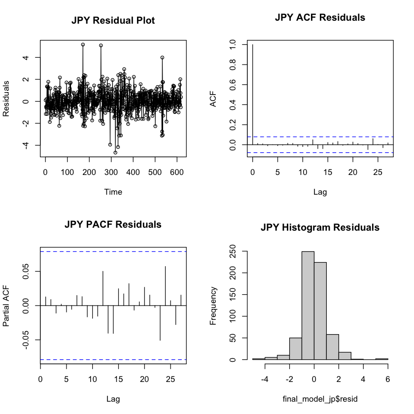

```
	Box-Pierce test

data:  final_model_cn$resid
X-squared = 0.050018, df = 1, p-value = 0.823
```

```
	Box-Ljung test

data:  final_model_cn$resid
X-squared = 0.050552, df = 1, p-value = 0.8221
```

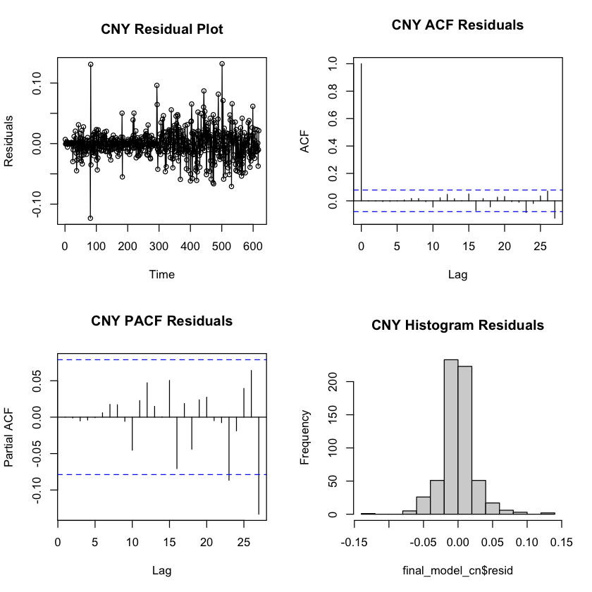

```r
par(mfrow = c(2, 2))
plot(final_model_jp$resid, ylab="Residuals", type = "o", main = "JPY Residual Plot")
acf(final_model_jp$resid, main = "JPY ACF Residuals")
pacf(final_model_jp$resid, main = "JPY PACF Residuals")
hist(final_model_jp$resid, main = "JPY Histogram Residuals")

Box.test(final_model_jp$resid, lag = (porderjp+qorderjp+1), type="Box-Pierce", fitdf=(porderjp+qorderjp))
Box.test(final_model_jp$resid, lag = (porderjp+qorderjp+1), type="Ljung-Box", fitdf=(porderjp+qorderjp))

par(mfrow = c(2, 2))
plot(final_model_cn$resid, ylab="Residuals", type="o", main = "CNY Residual Plot")
acf(final_model_cn$resid, main = "CNY ACF Residuals")
pacf(final_model_cn$resid, main = "CNY PACF Residuals")
hist(final_model_cn$resid, main = "CNY Histogram Residuals")
Box.test(final_model_cn$resid, lag = (pordercn+qordercn+1), type="Box-Pierce", fitdf=(pordercn+qordercn))
Box.test(final_model_cn$resid, lag = (pordercn+qordercn+1), type="Ljung-Box", fitdf=(pordercn+qordercn))
```

*Response: Residual Analysis*

**JPY**

The residual analysis of the final fitted model for the JPY dataset is shown above. The residuals are randomly scattered amongst 0 and do not display heterosketerdasicity. The variance of the residuals is stable over time. Further the autocorrelation function remains low in both the PACF and ACF indicating that seasonality and trend are well captured in the final model.

The hypothesis testing using the box-pierce and box-ljung methods return p-values greater than 0.05. This indicates that we fail to reject the null hypothesis that the data is not serially correlated.

**CNY**

The residual analysis of the final fitted model for the CNY dataset is shown above. The residuals show heteroskedasicity over the time period indicating the predicted value may deviate from the observed value more at the later time period. This observation is supported by the ACF and PACF plots where the autocorrelation function is larger at higher order lags. The spikes observed are just outside the confidence interval so it should be monitored going forward. There is not adequete evidence to show that the model is not a good fit to the data.

The hypothesis testing using the box-pierce and box-ljung methods return p-values greater than 0.05. This indicates that we fail to reject the null hypothesis that the data is not serially correlated.

**2c.** For each currency exchange, apply the model identified in (2a) and forecast the last eight weeks of data. Plot the predicted data to compare the predicted values to the actual observed ones. Include 90% confidence intervals for the forecasts in the corresponding plots.

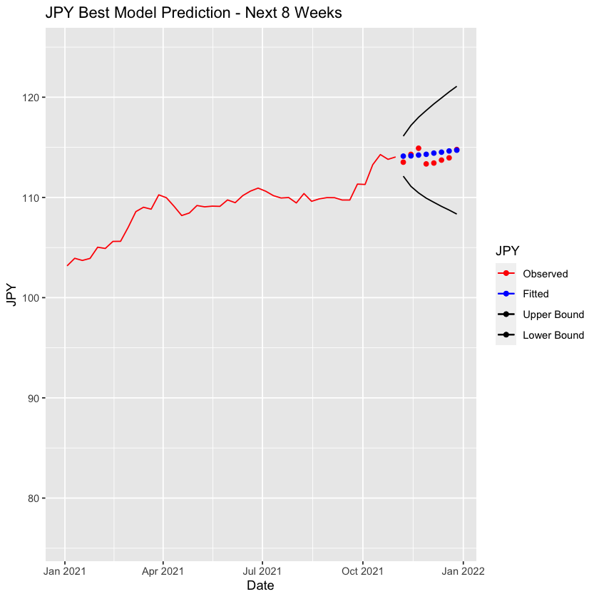

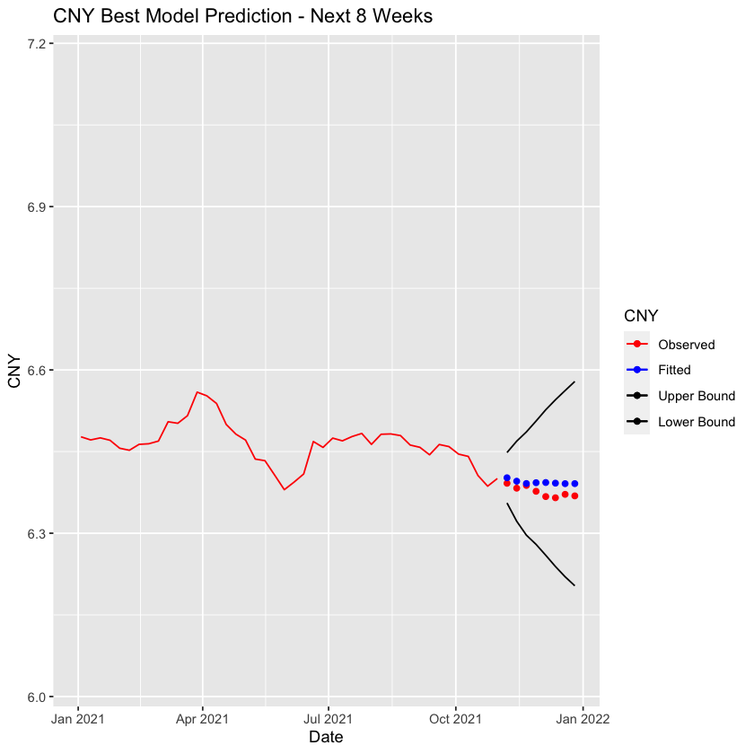

```r
outpredjpweekly = predict(final_model_jp, n.ahead=8)
uboundjpweekly = outpredjpweekly$pred+1.96*outpredjpweekly$se
lboundjpweekly = outpredjpweekly$pred-1.96*outpredjpweekly$se

ggplot() +
  geom_line(data = weekly.train, aes(x = Date, y = JPY, color="Observed")) +
  geom_point(data = weekly.test, aes(x = Date, y = JPY, color = "Observed")) +
  geom_point(data = weekly.test, aes(x = Date, y = outpredjpweekly$pred, color = "Fitted")) +
  geom_line(data = weekly.test, aes(x = Date, y = uboundjpweekly, color="Upper Bound")) +
  geom_line(data = weekly.test, aes(x = Date, y = lboundjpweekly, color="Lower Bound")) +
  xlab('Date') + xlim(as.Date(c('2021-01-01',max(weekly$Date)))) +
  ylab('JPY') + labs(title = 'JPY Best Model Prediction - Next 8 Weeks') + scale_color_manual(name='JPY',
                     breaks=c('Observed', 'Fitted', 'Upper Bound', 'Lower Bound'),
                     values=c('Observed'='red', 'Fitted'='blue', 'Upper Bound' = 'black', 'Lower Bound'='black'))

outpredcnweekly = predict(final_model_cn, n.ahead=8)
uboundcnweekly = outpredcnweekly$pred+1.96*outpredcnweekly$se
lboundcnweekly = outpredcnweekly$pred-1.96*outpredcnweekly$se

ggplot() +
  geom_line(data = weekly.train, aes(x = Date, y = CNY, color="Observed")) +
  geom_point(data = weekly.test, aes(x = Date, y = CNY, color = "Observed")) +
  geom_point(data = weekly.test, aes(x = Date, y = outpredcnweekly$pred, color = "Fitted")) +
  geom_line(data = weekly.test, aes(x = Date, y = uboundcnweekly, color="Upper Bound")) +
  geom_line(data = weekly.test, aes(x = Date, y = lboundcnweekly, color="Lower Bound")) +
  xlab('Date') + xlim(as.Date(c('2021-01-01',max(weekly$Date)))) +
  ylab('CNY') + labs(title = 'CNY Best Model Prediction - Next 8 Weeks') + scale_color_manual(name='CNY',
                     breaks=c('Observed', 'Fitted', 'Upper Bound', 'Lower Bound'),
                     values=c('Observed'='red', 'Fitted'='blue', 'Upper Bound' = 'black', 'Lower Bound'='black'))
```

**2d.** Calculate Mean Absolute Percentage Error (MAPE) and Precision Measure (PM). How many observations are within the prediction bands? Compare the accuracy of the predictions for the two time series using these two measures.

```r
### JPY
## MAPE
MAPE.JPY.Weekly = mean(abs(outpredjpweekly$pred-weekly.test$JPY)/weekly.test$JPY)
paste("The MAPE of the weekly JPY prediction is:", round(MAPE.JPY.Weekly, 3))
## PM
PM.JPY.Weekly = sum((outpredjpweekly$pred-weekly.test$JPY)^2)/sum((weekly.test$JPY-mean(weekly.test$JPY))^2)
paste("The PM of the weekly JPY prediction is:", round(PM.JPY.Weekly, 3))

### CNY
## MAPE
MAPE.CNY.Weekly = mean(abs(outpredcnweekly$pred-weekly.test$CNY)/weekly.test$CNY)
paste("The MAPE of the weekly CNY prediction is:", round(MAPE.CNY.Weekly, 3))
## PM
PM.CNY.Weekly = sum((outpredcnweekly$pred-weekly.test$CNY)^2)/sum((weekly.test$CNY-mean(weekly.test$CNY))^2)
paste("The PM of the weekly CNY prediction is:", round(PM.CNY.Weekly, 3))
```

'The MAPE of the weekly JPY prediction is: 0.005'

'The PM of the weekly JPY prediction is: 1.488'

'The MAPE of the weekly CNY prediction is: 0.003'

'The PM of the weekly CNY prediction is: 3.998'

*Response: Prediction Accuracy*

I can visually see that all observations are within the prediction bands.

Another observation is that the first 3 predictions in the CNY dataset are close to the observed values. However, the predictions deviate more after this point. This is expected because the confidence interval increases at timepoints further from the historical data.

# Question 3. ARIMA Fitting: Monthly Data Analysis (17 points)

**3a.** Divide the data into training and testing data set, where the training data exclude the last two months of data (November and December 2021) with the testing data including the last two months. For both currency exchange rates and using the training datasets, use the iterative model to fit an ARIMA(p,d,q) model with max AR and MA orders of 8, and a differencing order of 1 or 2. Display the summary of the final model fit. Compare statistical significance of the coefficients. Compare the order selection from using monthly versus weekly data for each of the two currencies.

```r
### Monthly

## JPY
options(warn = -1)
monthly.train = head(monthly, n=length(monthly$Date)-2)
monthly.test = tail(monthly, n=2)

norderpq = 8
norderd = 2


p = c(1:norderpq)-1; q = c(1:norderpq)-1; d = c(1:norderd)

aic1 = matrix(0, norderpq, norderpq)
aic2 = matrix(0, norderpq, norderpq)

for (i in 1:norderpq){
    for (j in 1:norderpq){
        for (k in 1:norderd){
            modijk = arima(monthly.train$JPY, order = c(p[i], d[k], q[j]), method = 'ML')
            if (k == 1){
                aic1[i,j] = modijk$aic-2*(p[i]+q[j]+1)+2*(p[i]+q[j]+1)*length(monthly.train)/(length(monthly.train)-p[i]-q[j]-2)
            } else {
                aic2[i,j] = modijk$aic-2*(p[i]+q[j]+1)+2*(p[i]+q[j]+1)*length(monthly.train)/(length(monthly.train)-p[i]-q[j]-2)
            }
        }
    }
}

aicv1 = as.vector(aic1)
indexp1 = rep(c(1:norderpq),norderpq)
indexq1 = rep(c(1:norderpq),each=norderpq)
indexaic1 = which(aicv1 == min(aicv1))
porder1 = indexp1[indexaic1]-1
qorder1 = indexq1[indexaic1]-1

minaic1 = aic1[porder1+1,qorder1+1]

aicv2 = as.vector(aic2)
indexp2 = rep(c(1:norderpq),norderpq)
indexq2 = rep(c(1:norderpq),each=norderpq)
indexaic2 = which(aicv2 == min(aicv2))
porder2 = indexp2[indexaic2]-1
qorder2 = indexq2[indexaic2]-1

minaic2 = aic1[porder2+1,qorder2+1]

if (minaic1 < minaic2){
    final_model_jp_monthly = arima(monthly.train$JPY, order = c(porder1, 1, qorder1), method = 'ML')
    porderjpmonthly = porder1
    qorderjpmonthly = qorder1
} else {
    final_model_jp_monthly = arima(monthly.train$JPY, order = c(porder2, 2, qorder2), method = 'ML')
    porderjpmonthly = porder2
    qorderjpmonthly = qorder2
}

## CNY
options(warn = -1)
monthly.train = head(monthly, n=length(monthly$Date)-2)
monthly.test = tail(monthly, n=2)

norderpq = 8
norderd = 2


p = c(1:norderpq)-1; q = c(1:norderpq)-1; d = c(1:norderd)

aic1 = matrix(0, norderpq, norderpq)
aic2 = matrix(0, norderpq, norderpq)

for (i in 1:norderpq){
    for (j in 1:norderpq){
        for (k in 1:norderd){
            modijk = arima(monthly.train$CNY, order = c(p[i], d[k], q[j]), method = 'ML')
            if (k == 1){
                aic1[i,j] = modijk$aic-2*(p[i]+q[j]+1)+2*(p[i]+q[j]+1)*length(monthly.train)/(length(monthly.train)-p[i]-q[j]-2)
            } else {
                aic2[i,j] = modijk$aic-2*(p[i]+q[j]+1)+2*(p[i]+q[j]+1)*length(monthly.train)/(length(monthly.train)-p[i]-q[j]-2)
            }
        }
    }
}

aicv1 = as.vector(aic1)
indexp1 = rep(c(1:norderpq),norderpq)
indexq1 = rep(c(1:norderpq),each=norderpq)
indexaic1 = which(aicv1 == min(aicv1))
porder1 = indexp1[indexaic1]-1
qorder1 = indexq1[indexaic1]-1

minaic1 = aic1[porder1+1,qorder1+1]

aicv2 = as.vector(aic2)
indexp2 = rep(c(1:norderpq),norderpq)
indexq2 = rep(c(1:norderpq),each=norderpq)
indexaic2 = which(aicv2 == min(aicv2))
porder2 = indexp2[indexaic2]-1
qorder2 = indexq2[indexaic2]-1

minaic2 = aic1[porder2+1,qorder2+1]

if (minaic1 < minaic2){
    final_model_cn_monthly = arima(monthly.train$CNY, order = c(porder1, 1, qorder1), method = 'ML')
    pordercnmonthly = porder1
    qordercnmonthly = qorder1
} else {
    final_model_cn_monthly = arima(monthly.train$CNY, order = c(porder2, 2, qorder2), method = 'ML')
    pordercnmonthly = porder2
    qordercnmonthly = qorder2
}
```

```r
# Displaying the summary of each model's fit
summary(final_model_jp_monthly)

summary(final_model_cn_monthly)
```

```
Call:
arima(x = monthly.train$JPY, order = c(porder1, 1, qorder1), method = "ML")

Coefficients:
          ar1     ar2      ar3     ar4      ar5      ar6     ma1      ma2
      -0.0700  0.4156  -0.6753  0.1724  -0.1318  -0.7814  0.0902  -0.2858
s.e.   0.0751  0.0693   0.0888  0.0693   0.0693   0.0613  0.0836   0.0928
         ma3      ma4     ma5     ma6
      0.8094  -0.2857  0.0902  1.0000
s.e.  0.0686   0.0933  0.0811  0.0991

sigma^2 estimated as 4.765:  log likelihood = -315.37,  aic = 656.74

Training set error measures:
                    ME    RMSE      MAE     MPE    MAPE      MASE        ACF1
Training set 0.1495756 2.17522 1.600358 0.12539 1.57017 0.9039941 0.005838354

Call:
arima(x = monthly.train$CNY, order = c(porder1, 1, qorder1), method = "ML")

Coefficients:
         ar1      ar2     ar3      ar4      ar5     ar6      ar7      ma1
      0.6508  -0.8655  0.1618  -0.2343  -0.4435  0.5926  -0.5340  -0.3582
s.e.  0.2447   0.1543  0.1871   0.1603   0.1169  0.1182   0.1436   0.2782
         ma2     ma3     ma4     ma5      ma6     ma7
      0.7564  0.2903  0.1177  0.7943  -0.7083  0.4390
s.e.  0.1732  0.2128  0.2050  0.1712   0.2145  0.2222

sigma^2 estimated as 0.003297:  log likelihood = 197.34,  aic = -364.67

Training set error measures:
                       ME       RMSE        MAE         MPE      MAPE      MASE
Training set -0.002086079 0.05722216 0.04284528 -0.03416097 0.6530161 0.8712798
                   ACF1
Training set 0.01304039
```

```r
## Compute the p-value of each coefficient

## Sample Code to compute the test statistics
tv.jpy.monthly <-as.numeric(final_model_jp_monthly$coef)/as.numeric(sqrt(diag(final_model_jp_monthly$var.coef)))
tv.cny.monthly <-as.numeric(final_model_cn_monthly$coef)/as.numeric(sqrt(diag(final_model_cn_monthly$var.coef)))

## Apply the pvalue.coef function
pvalues.jpy.monthly <- sapply(tv.jpy.monthly, pvalue.coef)
pvalues.cny.monthly <- sapply(tv.cny.monthly, pvalue.coef)

print("JPY Dataset Monthly")
pvalues.jpy.monthly

print("CNY Dataset Monthly")
pvalues.cny.monthly
```

```
[1] "JPY Dataset Monthly"
```

1. 0.350842955065797

2. 2.02873606802711e-09

3. 2.8643754035329e-14

4. 0.0128268048836471

5. 0.0573026557060436

6. 0

7. 0.280442979281109

8. 0.00208484670760356

9. 0

10. 0.00219772490802939

11. 0.26587462009916

12. 0

```
[1] "CNY Dataset Monthly"
```

1. 0.00781975331730855

2. 2.04813896953482e-08

3. 0.387080344683018

4. 0.143829890102582

5. 0.000148910238803035

6. 5.3439464831051e-07

7. 0.000200195004035564

8. 0.197849582752516

9. 1.26160449167578e-05

10. 0.172550264301604

11. 0.565920657551636

12. 3.50459379139245e-06

13. 0.000957277023083014

14. 0.048202735456325

*Response: Analysis of the ARIMA Fit for the Weekly and Monthly Data*

In both models there are coefficients that are and are not statistically significance. Because of this it may be worth exploring lower order models for the monthly data.

The MAPE value of the weekly models (JPY: 0.72, CNY: 0.24) are lower that that of the monthly models (JPY: 1.57, CNY: 0.65). This indicates that the weekly models are a better fit to the observed data.

*Response: Monthly vs Weekly Data*

The order selection of the models for monthly JPY (6, 1, 6) and CNY (7, 1, 7) are higher than that of the weekly data JPY (5, 1, 3) and CNY (5, 1, 0).

**3b.** For each currency exchange, apply the model identified in (3a) and forecast the last two months of data. Plot the predicted data to compare the predicted values to the actual observed ones. Include 90% confidence intervals for the forecasts in the corresponding plots.

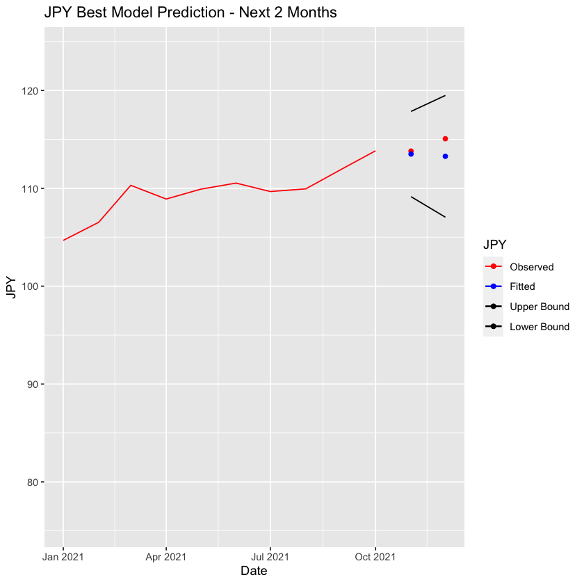

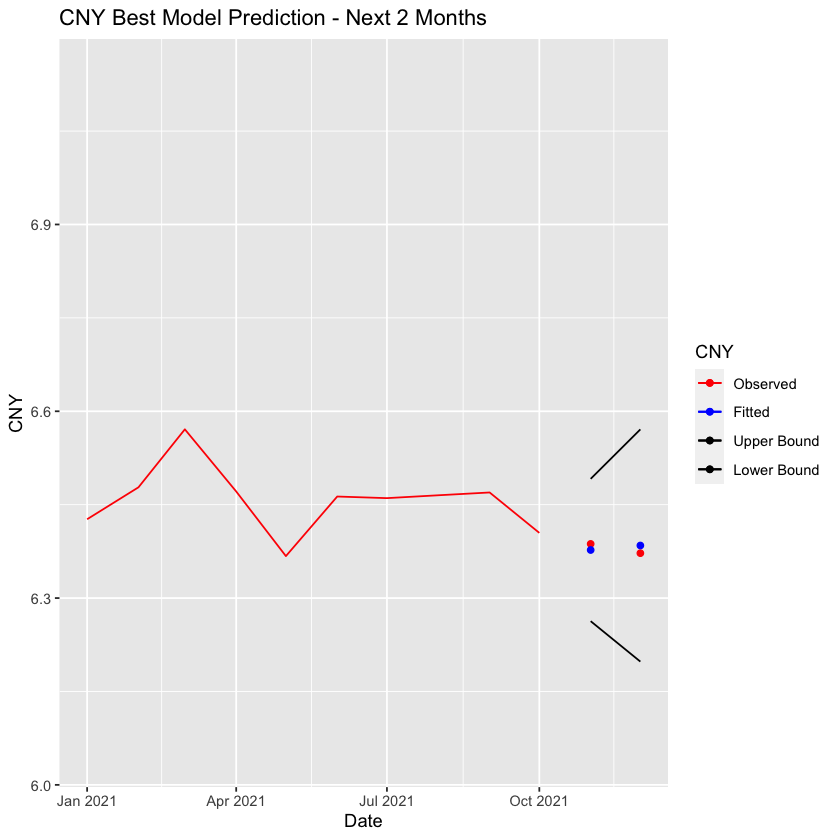

```r
outpredjpmonthly = predict(final_model_jp_monthly, n.ahead=2)
uboundjpmonthly = outpredjpmonthly$pred+1.96*outpredjpmonthly$se
lboundjpmonthly = outpredjpmonthly$pred-1.96*outpredjpmonthly$se

ggplot() +
  geom_line(data = monthly.train, aes(x = Date, y = JPY, color="Observed")) +
  geom_point(data = monthly.test, aes(x = Date, y = JPY, color = "Observed")) +
  geom_point(data = monthly.test, aes(x = Date, y = outpredjpmonthly$pred, color = "Fitted")) +
  geom_line(data = monthly.test, aes(x = Date, y = uboundjpmonthly, color="Upper Bound")) +
  geom_line(data = monthly.test, aes(x = Date, y = lboundjpmonthly, color="Lower Bound")) +
  xlab('Date') + xlim(as.Date(c('2021-01-01',max(monthly$Date)))) +
  ylab('JPY') + labs(title = 'JPY Best Model Prediction - Next 2 Months') + scale_color_manual(name='JPY',
                     breaks=c('Observed', 'Fitted', 'Upper Bound', 'Lower Bound'),
                     values=c('Observed'='red', 'Fitted'='blue', 'Upper Bound' = 'black', 'Lower Bound'='black'))

outpredcnmonthly = predict(final_model_cn_monthly, n.ahead=2)
uboundcnmonthly = outpredcnmonthly$pred+1.96*outpredcnmonthly$se
lboundcnmonthly = outpredcnmonthly$pred-1.96*outpredcnmonthly$se

ggplot() +
  geom_line(data = monthly.train, aes(x = Date, y = CNY, color="Observed")) +
  geom_point(data = monthly.test, aes(x = Date, y = CNY, color = "Observed")) +
  geom_point(data = monthly.test, aes(x = Date, y = outpredcnmonthly$pred, color = "Fitted")) +
  geom_line(data = monthly.test, aes(x = Date, y = uboundcnmonthly, color="Upper Bound")) +
  geom_line(data = monthly.test, aes(x = Date, y = lboundcnmonthly, color="Lower Bound")) +
  xlab('Date') + xlim(as.Date(c('2021-01-01',max(monthly$Date)))) +
  ylab('CNY') + labs(title = 'CNY Best Model Prediction - Next 2 Months') + scale_color_manual(name='CNY',
                     breaks=c('Observed', 'Fitted', 'Upper Bound', 'Lower Bound'),
                     values=c('Observed'='red', 'Fitted'='blue', 'Upper Bound' = 'black', 'Lower Bound'='black'))
```

**3c.** Calculate Mean Absolute Percentage Error (MAPE) and Precision Measure (PM). How many observations are within the prediction bands? Compare the accuracy of the predictions for the two time series using these two measures.

```r
### JPY
## MAPE
MAPE.JPY.Monthly = mean(abs(outpredjpmonthly$pred-monthly.test$JPY)/monthly.test$JPY)
paste("The MAPE of the monthly JPY prediction is:", round(MAPE.JPY.Monthly, 3))
## PM
PM.JPY.Monthly = sum((outpredjpmonthly$pred-monthly.test$JPY)^2)/sum((monthly.test$JPY-mean(monthly.test$JPY))^2)
paste("The PM of the monthly JPY prediction is:", round(PM.JPY.Monthly, 3))

### CNY
## MAPE
MAPE.CNY.Monthly = mean(abs(outpredcnmonthly$pred-monthly.test$CNY)/monthly.test$CNY)
paste("The MAPE of the monthly CNY prediction is:", round(MAPE.CNY.Monthly, 3))
## PM
PM.CNY.Monthly = sum((outpredcnmonthly$pred-monthly.test$CNY)^2)/sum((monthly.test$CNY-mean(monthly.test$CNY))^2)
paste("The PM of the monthly CNY prediction is:", round(PM.CNY.Monthly, 3))
```

'The MAPE of the monthly JPY prediction is: 0.009'

'The PM of the monthly JPY prediction is: 4.169'

'The MAPE of the monthly CNY prediction is: 0.002'

'The PM of the monthly CNY prediction is: 2.237'

*Response: Predictions*

The MAPE and PM of the CNY dataset is lower than that of the JPY dataset. This indicates CNY prediction were closer to the observed values than the JPY model. This observation is supported by the visual representation where the predicted data points are closer to the observed value for the CNY dataset model compared to the JPY model.

# Question 4. Weekly vs Monthly Forecasting (5 points)

Compare the forecasts based on the weekly versus monthly data. Overlay the forecast into one single plot for each of the two currency exchange rates. What can you say about using weekly versus monthly data?

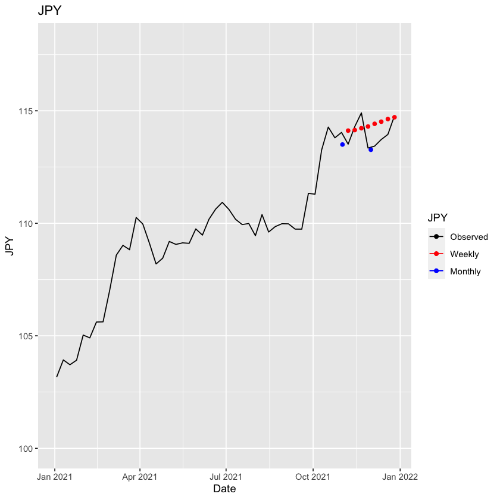

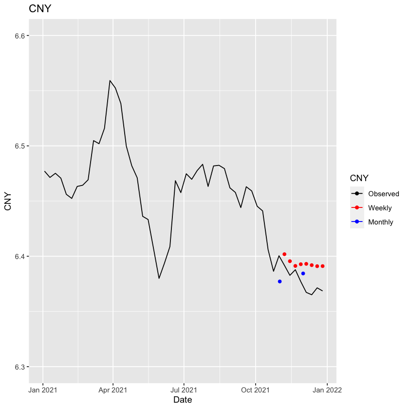

```r
# Plot JPY

ggplot() +
  geom_line(data = weekly, aes(x = Date, y = JPY, color="Observed")) +
  geom_point(data = weekly.test, aes(x = Date, y = outpredjpweekly$pred, color = "Weekly")) +
  geom_point(data = monthly.test, aes(x = Date, y = outpredjpmonthly$pred, color = "Monthly")) +
  xlab('Date') + xlim(as.Date(c('2021-01-01',max(monthly$Date)))) + ylim(c(100, 118)) +
  ylab('JPY') + labs(title = 'JPY') + scale_color_manual(name='JPY',
                     breaks=c('Observed', 'Weekly', 'Monthly'),
                     values=c('Observed'='black', 'Weekly'='red', 'Monthly' = 'blue'))

# Plot CNY

ggplot() +
  geom_line(data = weekly, aes(x = Date, y = CNY, color="Observed")) +
  geom_point(data = weekly.test, aes(x = Date, y = outpredcnweekly$pred, color = "Weekly")) +
  geom_point(data = monthly.test, aes(x = Date, y = outpredcnmonthly$pred, color = "Monthly")) +
  xlab('Date') + xlim(as.Date(c('2021-01-01',max(monthly$Date)))) + ylim(c(6.3, 6.6)) +
  ylab('CNY') + labs(title = 'CNY') + scale_color_manual(name='CNY',
                     breaks=c('Observed', 'Weekly', 'Monthly'),
                     values=c('Observed'='black', 'Weekly'='red', 'Monthly' = 'blue'))
```

*Response: Prediction Comparison*

The graphs above show the weekly and monthly predictions on the same plots for the JPY and CNY datasets.

My first observation is that the trend of the overall data is better captured in the weekly predictions as compared to the monthly predictions. This is because by average over the whole month, the week over week trend is removed. Further the week over week trend more closely follows the trend of the data closer than that of the monthly data.

# Question 5. Reflection on ARIMA (5 points)

Considering your understanding of the ARIMA model in general as well as what your understanding of the behavior of the currency exchange data based on the completion of the above questions, how would you personally regard the effectiveness of ARIMA modelling? Where would it be appropriate to use it for forecasting and where would you recommend against? What are some specific points of caution one would need to consider when considering using it?

*Response: Reflection on ARIMA*

The ARIMA model was effective at modelling each exchange rate but could be improved. This is because of the following

- Each dataset exhibited trend that was removed by differencing. By allowing differencing (d=1 in the ARIMA model), trend was removed and the the dataset exhibited weekly stationary behavior. This enabled a more accurate model by establishing constant mean and variance.
- The ACF plots of the differenced data does show some cyclical pattern indicating seasonality may be present. A SARIMA model should be explored to see if it improves the fit.
- The forecasting was appropriate when the number of forecasted data points is enough to generate an understanding of the forecast accuracy. Testing the forecast for only the next two months was not enough to understand if the forecast was accurate.
- Points of caution: (1) The confidence interval increases dramatically at time points further into the future. It would be benefitial to refit an arima at each future timepoint should the application allow. (2) It is difficult to gauge a models accuracy with only a small number of test points. The data should be split enough to allow an adequete test dataset. (3) The dataset did exhibit some seasonality as evidenced by differenced data ACF plot. A SARIMA model would account for this seasonality and likely improve the forecasting power of the model.